# Prototype implementation for 3cixty Nice KB

Rifat Ahmmad Rashid

In this implementation we presents, 3cixty Nice 2 class quality analysis report based on four quality characteristics: (i) Persistency (ii) Historical Persistency (iii) Consistency (iv) Completeness. We divided the report based on each quality characteristics. Also we presented 3cixty Nice 2 class growth analysis measure:

1. Class lode Event
2. Class dul Place

## Quality Problem Report Overview

### Input

In this implementation the datasets is presented in folder “~/ExperimentalData/3cixtyNice” where each class property count over 3cixtyNice 8 releases present in the CSV files. Also, the entity count of 2 classes presented in “3cixty2ClassEntityCount.csv” file.

```r
location="~/ExperimentalData/3cixtyNice/"
```

The dataset presented in the folder is already processed and build in a intermediate data structure for the quality assessment approach.

To run the rmd file only need to specify the folder location as input data.

### Results Structure

1. Persistency: A line graph presented to visualize variation on last two 3cixty Nice Release.
2. Historical Persistency: A table with this classes with persistency issues over the 8 Releases.
3. Consistency: Result of property values presented in a table. 1st table with incorrect property values and 2nd table with filtered property values
4. Completeness: Result of property values presented in a table with normalized property values and difference between two version of normalized property values.
5. KB growth: A graph visualizing KB growth.

## Experiment Results

Input: Set Entity file location such as -

```r
location<- "/ExperimentalData/3cixtyNice/"
```

### Class lode Event

[http://linkedevents.org/ontology/Event]

Input: set file location such as -

```r
location<- "/ExperimentalData/3cixtyNice/"
```

#### Persistency

Persistency Measure Result: 2016-09-09 value 689 < 2016-06-15 value 2182 Persistency=0

| Release | class | count |
| --- | --- | --- |
| 2016-03-11 | lode-Events | 605 |
| 2016-03-22 | lode-Events | 605 |
| 2016-04-09 | lode-Events | 1301 |
| 2016-05-03 | lode-Events | 1301 |
| 2016-05-13 | lode-Events | 1409 |
| 2016-05-27 | lode-Events | 1883 |
| 2016-06-15 | lode-Events | 2182 |
| 2016-09-09 | lode-Events | 689 |

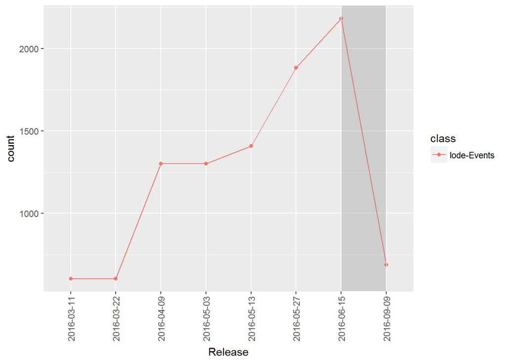

#### Historical Persitency

Historical Persistency Measure Result:

Total no. of class = 2 No. of persistency=1 HistPersistencyMeasure= 85.7142857 %

Releases with persistency values:

| Release | class | count | Persistency |
| --- | --- | --- | --- |
| 2016-03-11 | lode-Events | 605 | 1 |
| 2016-03-22 | lode-Events | 605 | 1 |
| 2016-04-09 | lode-Events | 1301 | 1 |
| 2016-05-03 | lode-Events | 1301 | 1 |
| 2016-05-13 | lode-Events | 1409 | 1 |
| 2016-05-27 | lode-Events | 1883 | 1 |
| 2016-06-15 | lode-Events | 2182 | 1 |
| 2016-09-09 | lode-Events | 689 | 0 |

#### Consistency

List of properties:

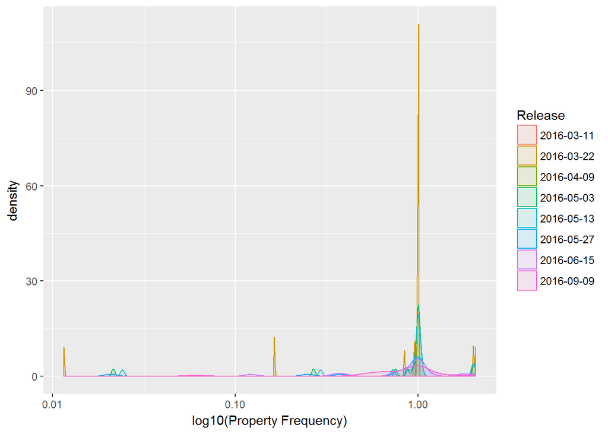

|  | Release | Property | freq | count | class | NormalizedFreq |
| --- | --- | --- | --- | --- | --- | --- |
| 110 | 2016-06-15 | http://data.linkedevents.org/def/location#businessType | 2182 | 2182 | lode-Events | 1.0000000 |
| 112 | 2016-06-15 | http://linkedevents.org/ontology/atPlace | 1632 | 2182 | lode-Events | 0.7479377 |
| 113 | 2016-06-15 | http://linkedevents.org/ontology/atTime | 2014 | 2182 | lode-Events | 0.9230064 |
| 114 | 2016-06-15 | http://linkedevents.org/ontology/hasCategory | 1698 | 2182 | lode-Events | 0.7781852 |
| 115 | 2016-06-15 | http://linkedevents.org/ontology/inSpace | 2182 | 2182 | lode-Events | 1.0000000 |
| 116 | 2016-06-15 | http://linkedevents.org/ontology/involvedAgent | 266 | 2182 | lode-Events | 0.1219065 |
| 118 | 2016-06-15 | http://purl.org/dc/elements/1.1/description | 2024 | 2182 | lode-Events | 0.9275894 |
| 120 | 2016-06-15 | http://purl.org/dc/elements/1.1/publisher | 2182 | 2182 | lode-Events | 1.0000000 |
| 122 | 2016-06-15 | http://www.3cixty.com/ontology#descriptionScore | 2182 | 2182 | lode-Events | 1.0000000 |
| 123 | 2016-06-15 | http://www.3cixty.com/ontology#posterScore | 2182 | 2182 | lode-Events | 1.0000000 |
| 126 | 2016-06-15 | http://www.w3.org/2000/01/rdf-schema#seeAlso | 851 | 2182 | lode-Events | 0.3900092 |
| 127 | 2016-06-15 | http://www.w3.org/2002/07/owl#sameAs | 1777 | 2182 | lode-Events | 0.8143905 |
| 128 | 2016-06-15 | http://purl.org/dc/elements/1.1/identifier | 770 | 2182 | lode-Events | 0.3528873 |
| 129 | 2016-09-09 | http://data.linkedevents.org/def/location#businessType | 689 | 689 | lode-Events | 1.0000000 |
| 131 | 2016-09-09 | http://linkedevents.org/ontology/atPlace | 424 | 689 | lode-Events | 0.6153846 |
| 132 | 2016-09-09 | http://linkedevents.org/ontology/atTime | 490 | 689 | lode-Events | 0.7111756 |
| 133 | 2016-09-09 | http://linkedevents.org/ontology/hasCategory | 584 | 689 | lode-Events | 0.8476052 |
| 134 | 2016-09-09 | http://linkedevents.org/ontology/inSpace | 689 | 689 | lode-Events | 1.0000000 |
| 135 | 2016-09-09 | http://linkedevents.org/ontology/involvedAgent | 42 | 689 | lode-Events | 0.0609579 |
| 136 | 2016-09-09 | http://linkedevents.org/ontology/poster | 380 | 689 | lode-Events | 0.5515239 |
| 137 | 2016-09-09 | http://purl.org/dc/elements/1.1/description | 650 | 689 | lode-Events | 0.9433962 |
| 138 | 2016-09-09 | http://purl.org/dc/elements/1.1/issued | 684 | 689 | lode-Events | 0.9927431 |
| 139 | 2016-09-09 | http://purl.org/dc/elements/1.1/publisher | 689 | 689 | lode-Events | 1.0000000 |
| 141 | 2016-09-09 | http://www.3cixty.com/ontology#descriptionScore | 689 | 689 | lode-Events | 1.0000000 |
| 142 | 2016-09-09 | http://www.3cixty.com/ontology#posterScore | 689 | 689 | lode-Events | 1.0000000 |
| 144 | 2016-09-09 | http://www.w3.org/2000/01/rdf-schema#label | 686 | 689 | lode-Events | 0.9956459 |
| 145 | 2016-09-09 | http://www.w3.org/2000/01/rdf-schema#seeAlso | 334 | 689 | lode-Events | 0.4847605 |
| 146 | 2016-09-09 | http://www.w3.org/2002/07/owl#sameAs | 439 | 689 | lode-Events | 0.6371553 |
| 147 | 2016-09-09 | http://purl.org/dc/elements/1.1/identifier | 453 | 689 | lode-Events | 0.6574746 |
| 148 | 2016-09-09 | http://3cixty.com/ontology#minDistanceNearestWeatherStation | 689 | 689 | lode-Events | 1.0000000 |
| 149 | 2016-09-09 | http://3cixty.com/ontology#nearestWeatherStation | 689 | 689 | lode-Events | 1.0000000 |

#### Completeness

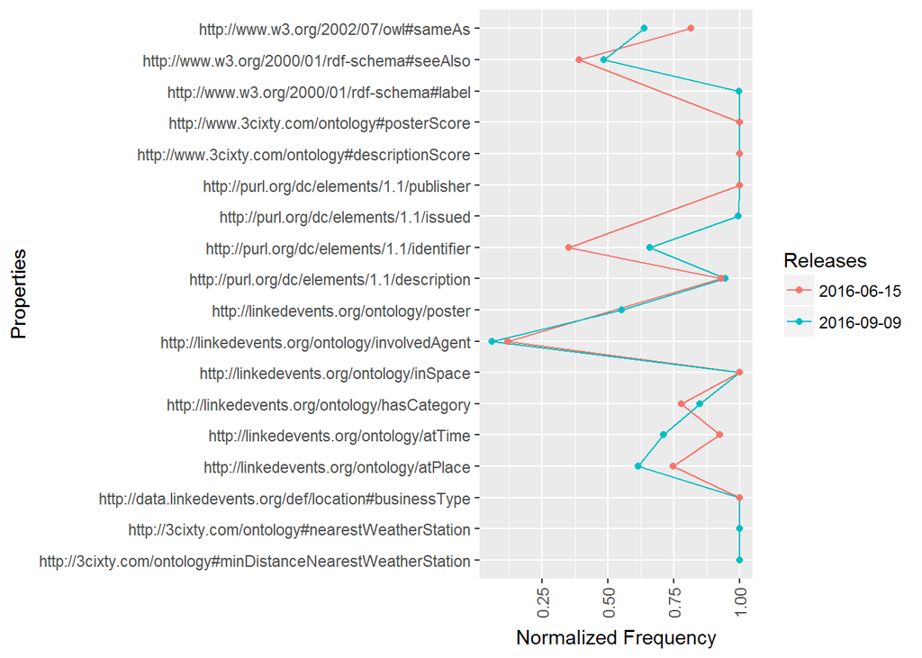

No. of incomplete properties= 8. Percentage of completeness=61.9047619 %

List of Incomplete properties list:

| Property | X2016.09.09 | X2016.06.15 | NormFreqDiff |
| --- | --- | --- | --- |
| http://linkedevents.org/ontology/atPlace | 0.6153846 | 0.7479377 | -0.1325531 |
| http://linkedevents.org/ontology/atTime | 0.7111756 | 0.9230064 | -0.2118308 |
| http://linkedevents.org/ontology/involvedAgent | 0.0609579 | 0.1219065 | -0.0609486 |
| http://linkedevents.org/ontology/poster | 0.5515239 | 1.0022915 | -0.4507675 |
| http://purl.org/dc/elements/1.1/issued | 0.9927431 | 1.1342805 | -0.1415374 |
| http://purl.org/dc/elements/1.1/subject | 1.4804064 | 1.7241063 | -0.2436999 |
| http://www.w3.org/2000/01/rdf-schema#label | 0.9956459 | 1.0032081 | -0.0075622 |
| http://www.w3.org/2002/07/owl#sameAs | 0.6371553 | 0.8143905 | -0.1772352 |

#### KB growth

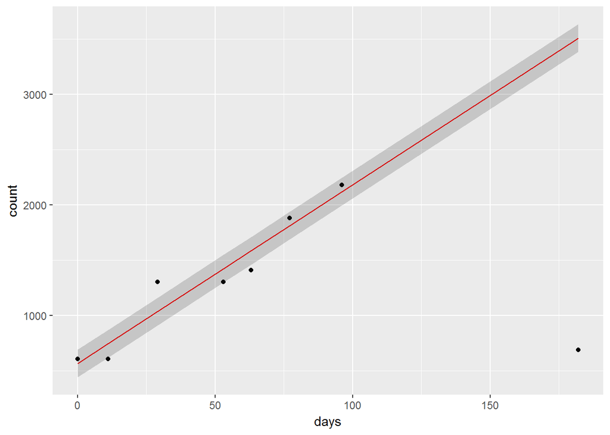

The normalized distance(ND)= 22.5481796

KB growth is 1 if ND<1 or KB growth is 0 if ND>=1

KB growth=0

### Class dul Place

[http://www.ontologydesignpatterns.org/ont/dul/DUL.owl#Place]

#### Persistency

|  | Release | class | count |
| --- | --- | --- | --- |
| 9 | 2016-03-11 | dul-Places | 20692 |
| 10 | 2016-03-22 | dul-Places | 20692 |
| 11 | 2016-04-09 | dul-Places | 27858 |
| 12 | 2016-05-03 | dul-Places | 26066 |
| 13 | 2016-05-13 | dul-Places | 26827 |
| 14 | 2016-05-27 | dul-Places | 25828 |
| 15 | 2016-06-15 | dul-Places | 41018 |
| 16 | 2016-09-09 | dul-Places | 44968 |

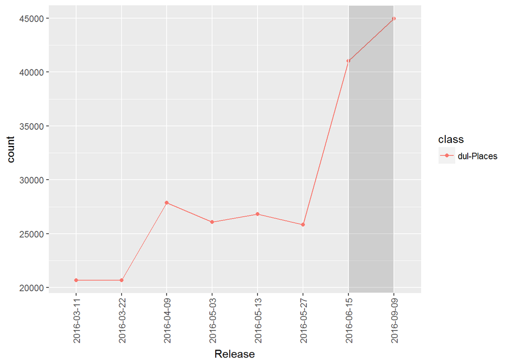

#### Historical Persitency

Releases with persistency values:

|  | Release | class | count | Persistency |
| --- | --- | --- | --- | --- |
| 9 | 2016-03-11 | dul-Places | 20692 | 1 |
| 10 | 2016-03-22 | dul-Places | 20692 | 1 |
| 11 | 2016-04-09 | dul-Places | 27858 | 1 |
| 12 | 2016-05-03 | dul-Places | 26066 | 0 |
| 13 | 2016-05-13 | dul-Places | 26827 | 1 |
| 14 | 2016-05-27 | dul-Places | 25828 | 0 |
| 15 | 2016-06-15 | dul-Places | 41018 | 1 |
| 16 | 2016-09-09 | dul-Places | 44968 | 1 |

Historical Persistency Measure Result: Total no. of class = 2 No. of persistency=2 HistPersistencyMeasure= 71.4285714 %

#### Consistency

List of properties:

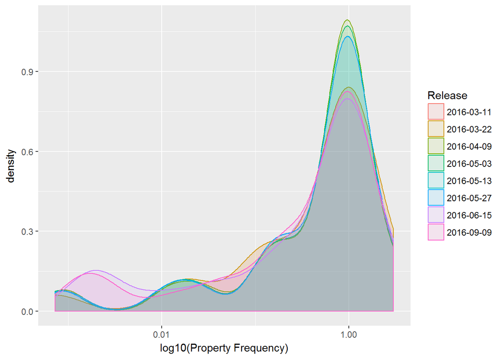

|  | Release | Property | freq | count | class | NormalizedFreq |
| --- | --- | --- | --- | --- | --- | --- |
| 142 | 2016-06-15 | http://linkedevents.org/ontology/poster | 37570 | 41018 | dul-Places | 0.9159393 |
| 145 | 2016-06-15 | http://schema.org/aggregateRating | 1280 | 41018 | dul-Places | 0.0312058 |
| 146 | 2016-06-15 | http://schema.org/description | 435 | 41018 | dul-Places | 0.0106051 |
| 147 | 2016-06-15 | http://schema.org/image | 23470 | 41018 | dul-Places | 0.5721878 |
| 148 | 2016-06-15 | http://schema.org/interactionCount | 7607 | 41018 | dul-Places | 0.1854552 |
| 149 | 2016-06-15 | http://schema.org/location | 40903 | 41018 | dul-Places | 0.9971964 |
| 150 | 2016-06-15 | http://schema.org/openingHours | 6459 | 41018 | dul-Places | 0.1574675 |
| 151 | 2016-06-15 | http://schema.org/priceRange | 67 | 41018 | dul-Places | 0.0016334 |
| 152 | 2016-06-15 | http://schema.org/review | 9564 | 41018 | dul-Places | 0.2331659 |
| 153 | 2016-06-15 | http://schema.org/telephone | 33143 | 41018 | dul-Places | 0.8080111 |
| 154 | 2016-06-15 | http://schema.org/url | 9960 | 41018 | dul-Places | 0.2428202 |
| 160 | 2016-06-15 | http://www.w3.org/2002/07/owl#sameAs | 39743 | 41018 | dul-Places | 0.9689161 |
| 162 | 2016-06-15 | http://data.ign.fr/def/topo#importance | 66 | 41018 | dul-Places | 0.0016090 |
| 163 | 2016-06-15 | http://vocab.org/transit/terms/route | 2320 | 41018 | dul-Places | 0.0565605 |
| 164 | 2016-06-15 | http://www.w3.org/2000/01/rdf-schema#seeAlso | 122 | 41018 | dul-Places | 0.0029743 |
| 168 | 2016-09-09 | http://linkedevents.org/ontology/poster | 8323 | 44968 | dul-Places | 0.1850872 |
| 171 | 2016-09-09 | http://schema.org/aggregateRating | 1720 | 44968 | dul-Places | 0.0382494 |
| 172 | 2016-09-09 | http://schema.org/description | 600 | 44968 | dul-Places | 0.0133428 |
| 173 | 2016-09-09 | http://schema.org/image | 25290 | 44968 | dul-Places | 0.5623999 |
| 174 | 2016-09-09 | http://schema.org/interactionCount | 11844 | 44968 | dul-Places | 0.2633873 |
| 175 | 2016-09-09 | http://schema.org/location | 44692 | 44968 | dul-Places | 0.9938623 |
| 176 | 2016-09-09 | http://schema.org/openingHours | 6281 | 44968 | dul-Places | 0.1396771 |
| 177 | 2016-09-09 | http://schema.org/priceRange | 60 | 44968 | dul-Places | 0.0013343 |
| 178 | 2016-09-09 | http://schema.org/review | 10697 | 44968 | dul-Places | 0.2378803 |
| 179 | 2016-09-09 | http://schema.org/telephone | 35371 | 44968 | dul-Places | 0.7865816 |
| 180 | 2016-09-09 | http://schema.org/url | 9982 | 44968 | dul-Places | 0.2219801 |
| 186 | 2016-09-09 | http://www.w3.org/2002/07/owl#sameAs | 43538 | 44968 | dul-Places | 0.9681996 |
| 188 | 2016-09-09 | http://data.ign.fr/def/topo#importance | 67 | 44968 | dul-Places | 0.0014899 |
| 189 | 2016-09-09 | http://vocab.org/transit/terms/route | 2523 | 44968 | dul-Places | 0.0561066 |
| 190 | 2016-09-09 | http://www.w3.org/2000/01/rdf-schema#seeAlso | 124 | 44968 | dul-Places | 0.0027575 |

#### Completeness

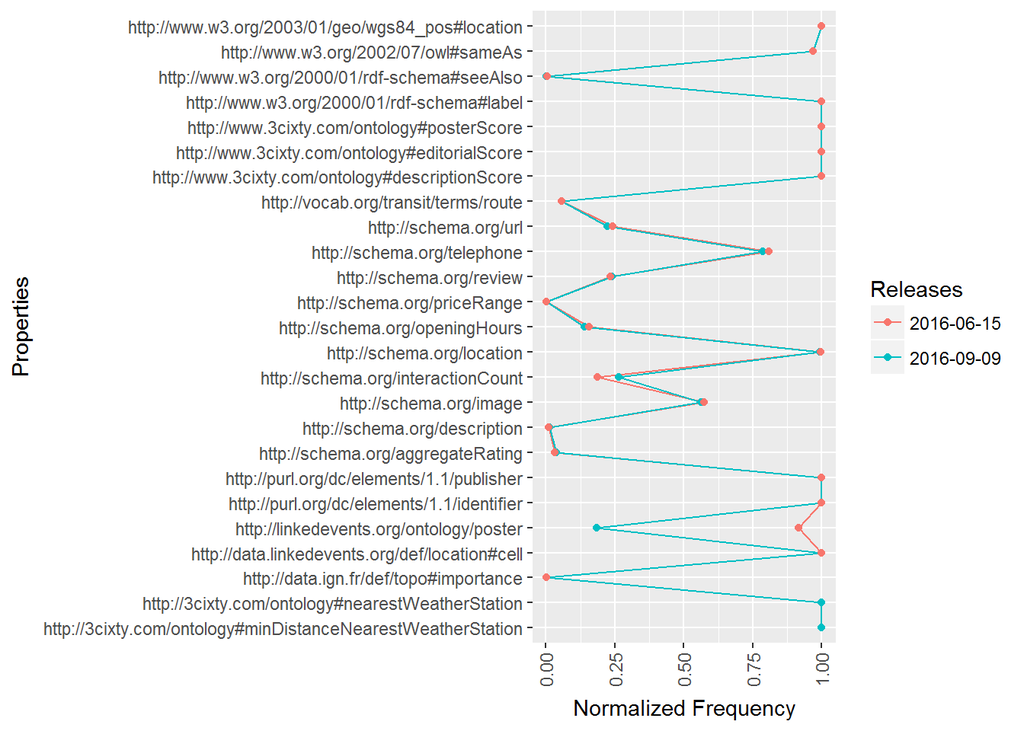

No. of incomplete properties= 14. Percentage of completeness=50 %

List of Incomplete properties:

| Property | X2016.09.09 | X2016.06.15 | NormFreqDiff |
| --- | --- | --- | --- |
| http://data.ign.fr/def/topo#importance | 0.0014899 | 0.0016090 | -0.0001191 |
| http://data.linkedevents.org/def/location#businessType | 2.7888721 | 2.8952167 | -0.1063446 |
| http://data.linkedevents.org/def/location#businessTypeTop | 1.0357365 | 1.0871081 | -0.0513716 |
| http://linkedevents.org/ontology/poster | 0.1850872 | 0.9159393 | -0.7308522 |
| http://schema.org/image | 0.5623999 | 0.5721878 | -0.0097879 |
| http://schema.org/location | 0.9938623 | 0.9971964 | -0.0033341 |
| http://schema.org/openingHours | 0.1396771 | 0.1574675 | -0.0177903 |
| http://schema.org/priceRange | 0.0013343 | 0.0016334 | -0.0002991 |
| http://schema.org/telephone | 0.7865816 | 0.8080111 | -0.0214295 |
| http://schema.org/url | 0.2219801 | 0.2428202 | -0.0208402 |
| http://vocab.org/transit/terms/route | 0.0561066 | 0.0565605 | -0.0004540 |
| http://www.w3.org/1999/02/22-rdf-syntax-ns#type | 2.9716910 | 2.9719635 | -0.0002725 |
| http://www.w3.org/2000/01/rdf-schema#seeAlso | 0.0027575 | 0.0029743 | -0.0002168 |
| http://www.w3.org/2002/07/owl#sameAs | 0.9681996 | 0.9689161 | -0.0007165 |

#### KB growth

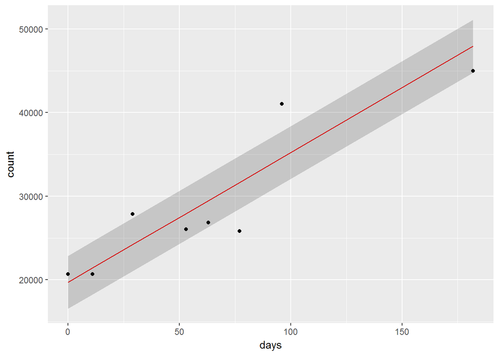

The normalized distance(ND)= 0.9411357

KB growth condition is 1 if ND<1 or KB growth is 0 if ND>=1

KB growth=1